# The Giver Unfolded

[figure not shown]

[figure not shown]

[figure not shown]

[figure not shown]

[figure not shown]

[figure not shown]

[figure not shown]

# Chapter 1 Analysis

## Project Introduction

14% of adults in the United States are functionally illiterate. “Functionally illiterate” is defined as reading below the 4th grade reading level. Many adults enroll in literacy tutoring programs that assist them with increasing their reading level to either, 1) complete their GED, 2) enroll in college or enter the workforce, 3) assist their children at home, or 4) other personal learning goals. These agencies are not equip with adult reading materials purely because they don’t exist. Instead, agencies provide their tutors with children’s books that are complementary to their adult learner’s reading level. Children books are not topically engaging or relevant to most adult learners. I examine the parts of speech found within *The Giver* - a book found in most 8th grade curriculum across the country - to help conceptualize what concepts should be taught at the 8th grade level. This project is the beginning of a large-scale examination of 4th through 8th grade books to assist with creating a formula to be used in establishing adult reading materials.

The first plot is a display of the parts of speech throughout Chapter 1. This plot allowed me to test the cleanNLP package and understand how parts of speech were categorized.

[output not shown]

### Version 1

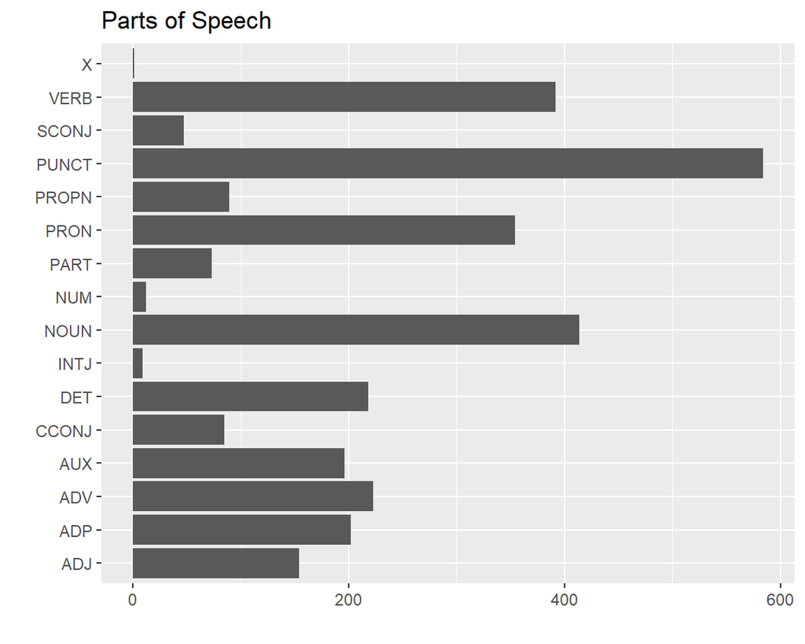

### Version 2

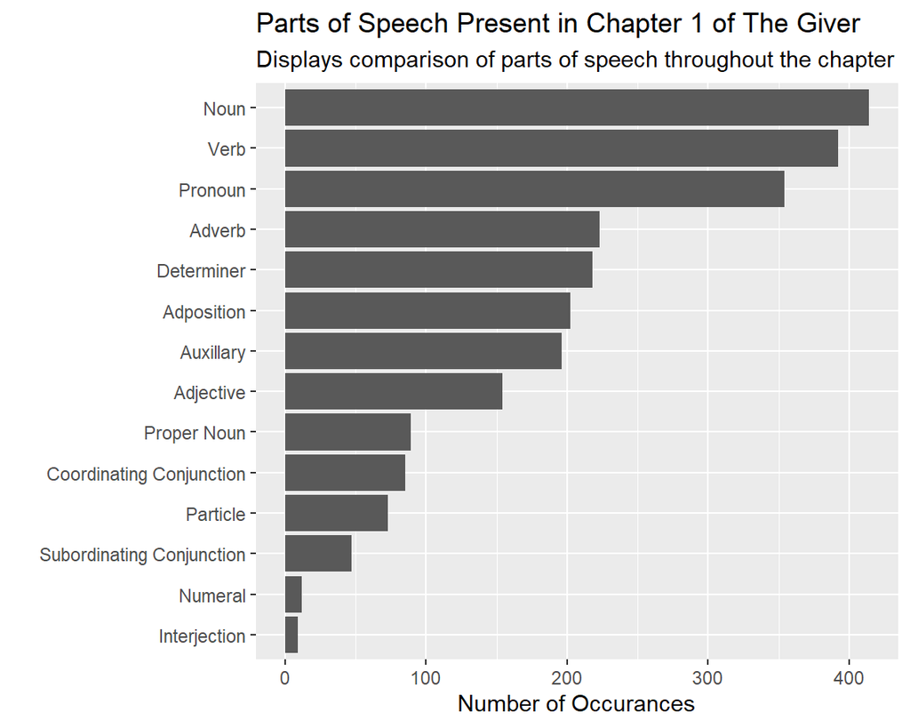

### Final Version

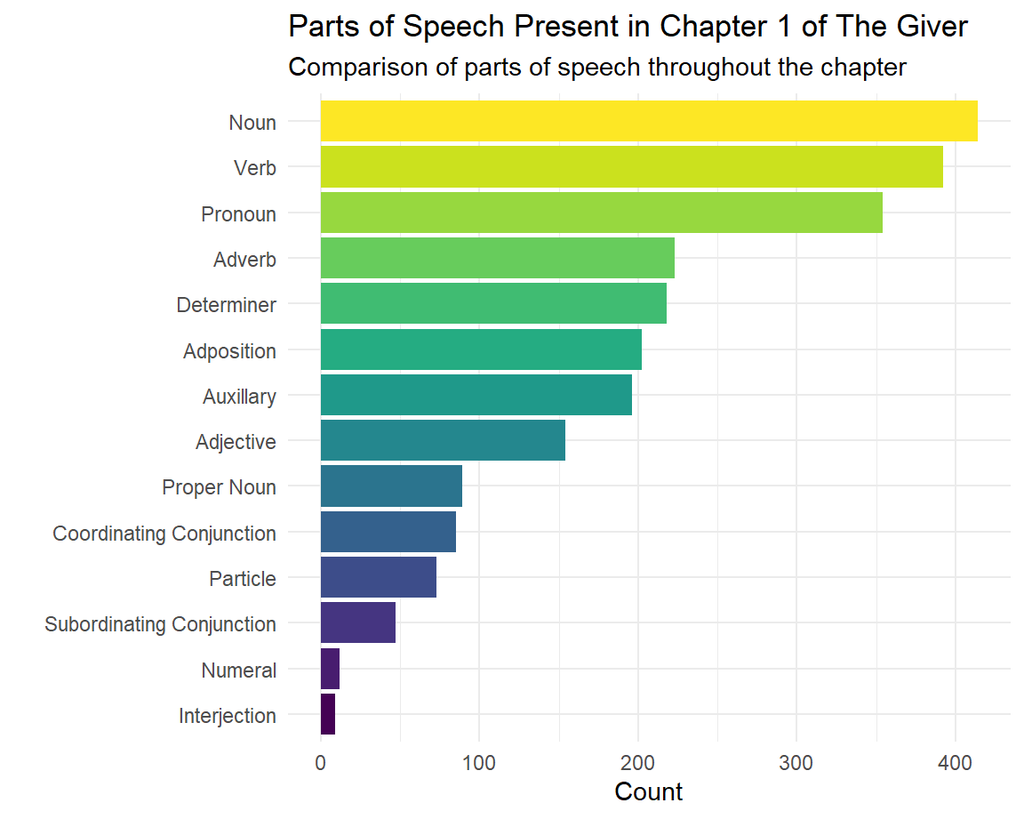

# Cross-Chapter Examination

## Cross-Chapter Analysis

[output not shown]

[output not shown]

[output not shown]

[output not shown]

[output not shown]

[output not shown]

[output not shown]

[output not shown]

[output not shown]

[output not shown]

[output not shown]

[output not shown]

[output not shown]

[output not shown]

[output not shown]

[output not shown]

[output not shown]

[output not shown]

[output not shown]

[output not shown]

[output not shown]

[output not shown]

### Version 1

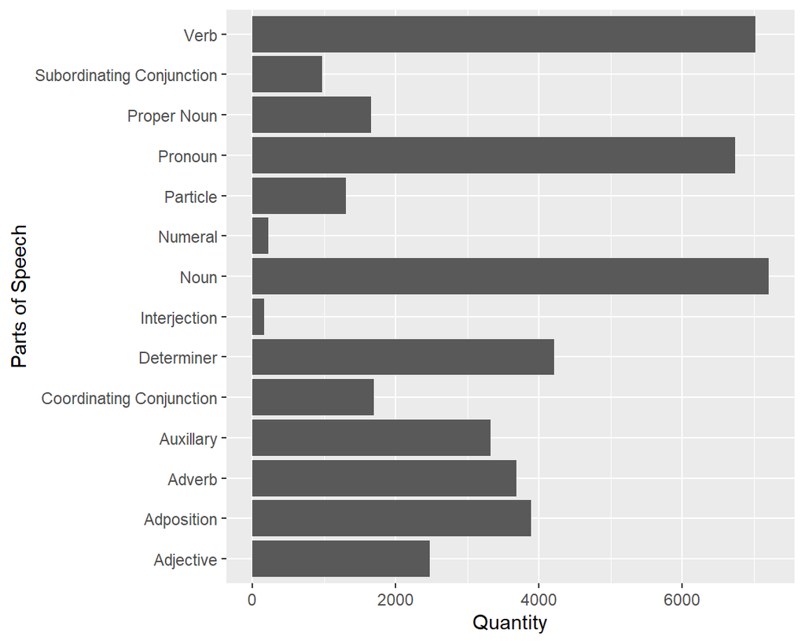

# Isolate Verbs

## Why Verbs?

Verbs are an indication of action and speech occurring in a novel. I wanted to examine the rises and falls of verbs throughout *The Giver* to see if I could determine a pattern that mirrors the plot. You will see there are three distinct rises in the amount of verbs found at the beginning, middle, and a few chapters before the end. This follows a common plot line where an introduction occurs in the beginning of a novel, with the climax of events in the middle, and the last hurrah before the final concluding details.

### Version 1

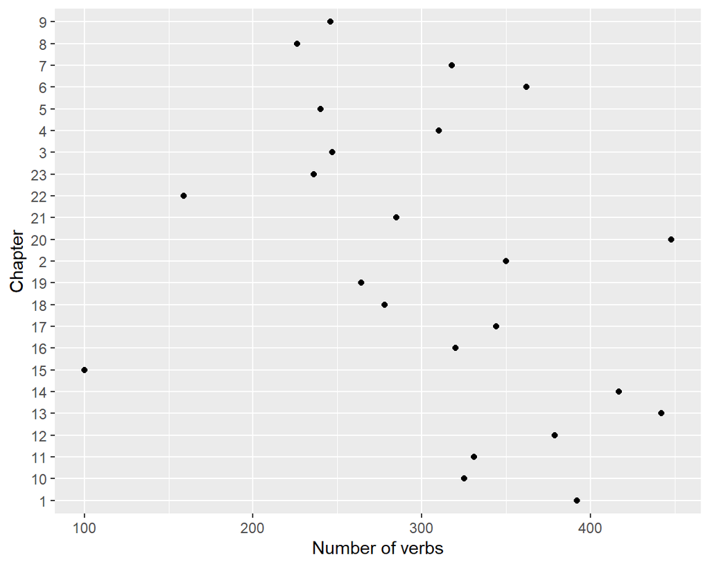

### Version 2

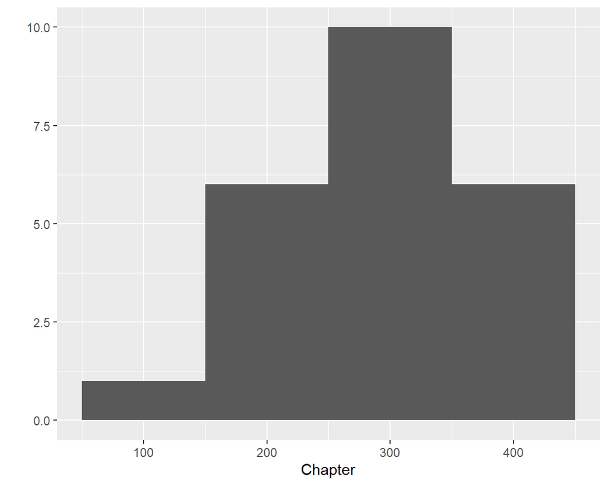

### Final Version

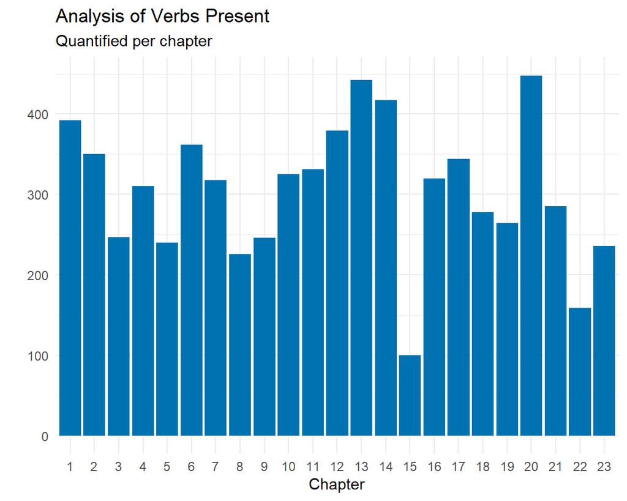